# Shipping Prediction Models

Karolina Dyrla-Mularczyk

2025-01-23

## Introduction

An international e-commerce company specializing in electronic products aims to analyze its customer database to gain valuable insights and improve operational efficiency. The company is leveraging advanced machine learning techniques to better understand factors influencing shipment delivery and customer behavior.

### **Goal of the Analysis**

The primary goal of this analysis is to gain insights from the customer shipping data of an e-commerce company. The objective is to explore, visualize relationships within the data, and build predictive models that can forecast whether a shipment will arrive on time or not. By understanding the key factors influencing on-time delivery, we aim to create a robust model that can assist in decision-making and improve operational efficiency.

The analysis will begin with a thorough exploration of the dataset, followed by visualization of key relationships between variables. This will be followed by the development of predictive models using machine learning techniques to accurately predict on-time deliveries.

## Data Exploration

### **Objective**

In this section, we explore the dataset to understand its structure, check for missing values, and prepare the data for further analysis.

### **Structure and Summary**

First, we take a look at the general structure of the data and check for missing values:

```
##  Warehouse_block Mode_of_Shipment Customer_care_calls Customer_rating
##  A:1833          Flight:1777      Min.   :2.000       Min.   :1.000
##  B:1833          Road  :1760      1st Qu.:3.000       1st Qu.:2.000
##  C:1833          Ship  :7462      Median :4.000       Median :3.000
##  D:1834                           Mean   :4.054       Mean   :2.991
##  F:3666                           3rd Qu.:5.000       3rd Qu.:4.000
##                                   Max.   :7.000       Max.   :5.000
##  Cost_of_the_Product Prior_purchases  Product_importance Gender
##  Min.   : 96.0       Min.   : 2.000   high  : 948        F:5545
##  1st Qu.:169.0       1st Qu.: 3.000   low   :5297        M:5454
##  Median :214.0       Median : 3.000   medium:4754
##  Mean   :210.2       Mean   : 3.568
##  3rd Qu.:251.0       3rd Qu.: 4.000
##  Max.   :310.0       Max.   :10.000
##  Discount_offered Weight_in_gms   Reached.on.Time_Y.N
##  Min.   : 1.00    Min.   :1001   Not On Time:4436
##  1st Qu.: 4.00    1st Qu.:1840   On Time    :6563
##  Median : 7.00    Median :4149
##  Mean   :13.37    Mean   :3634
##  3rd Qu.:10.00    3rd Qu.:5050
##  Max.   :65.00    Max.   :7846
```

### **Data Preparation**

To simplify the data analysis, unnecessary columns are removed, and categorical data is transformed into factors:

- Unnecessary columns such as ID are removed.
- Categorical columns such as Warehouse_block, Mode_of_Shipment, Product_importance, and Gender are transformed into factors for better handling in machine learning models.

### **Items in Warehouse Blocks**

In this visualization, we see the distribution of products across different warehouse blocks, highlighting where the most inventory is held.

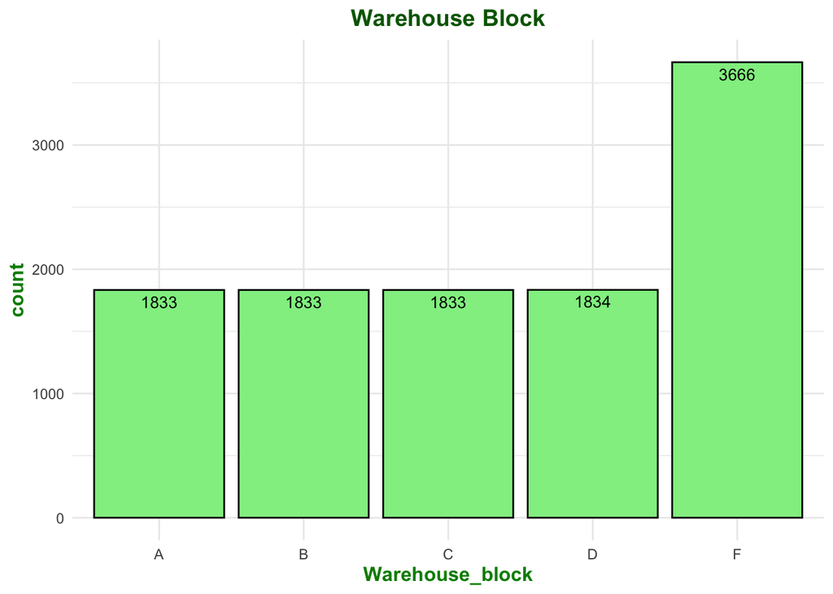

### **Different Shipping Methods**

This visualization represents the distribution of shipping methods used by the company.

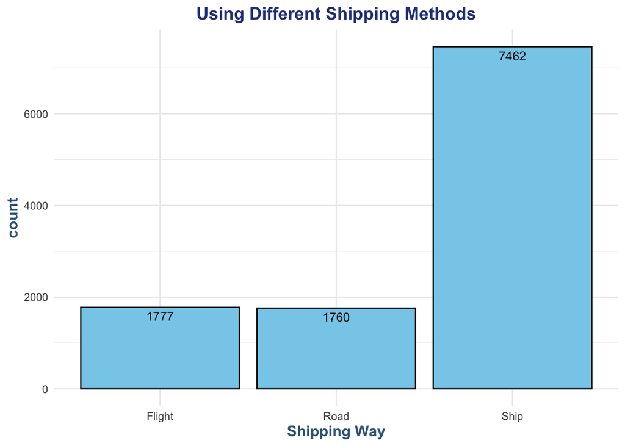

### **Customer Rating**

This bar chart shows how customers rate products in terms of their satisfaction.

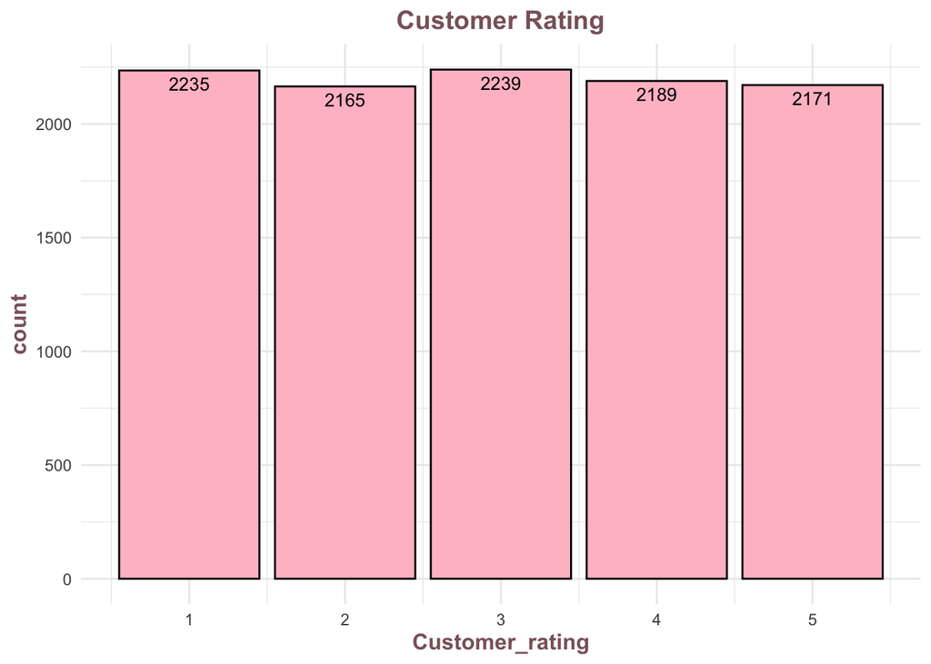

### **Weight by Mode of Shipment**

This boxplot illustrates the distribution of product weights across different shipping methods.

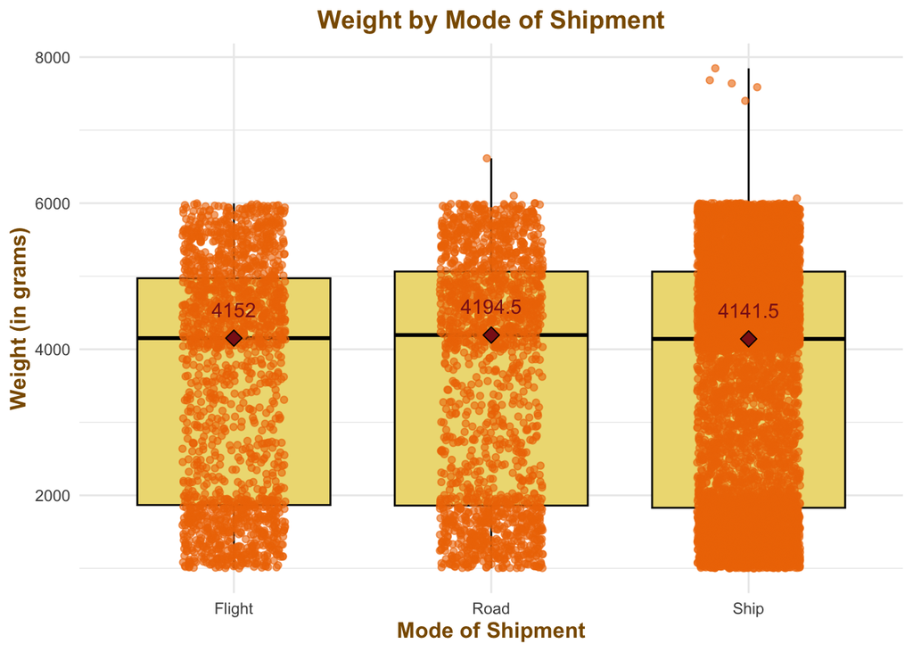

### **Ratings and On-Time Delivery**

This bar chart illustrates how customer ratings are distributed based on whether the products were delivered on time or not. It highlights potential relationships between delivery punctuality and customer satisfaction levels.

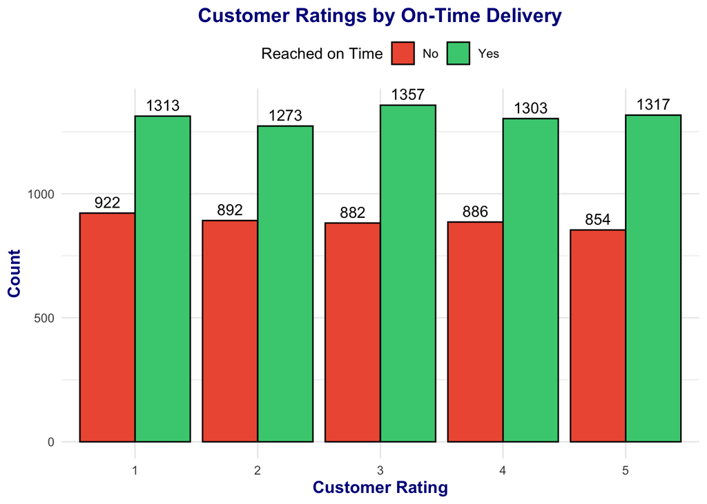

### **Correlation Between Numerical Variables**

The heatmap provides a clear visualization of the correlations between numerical variables in the dataset. It helps identify relationships and dependencies, which could be useful for decision-making and further analysis.

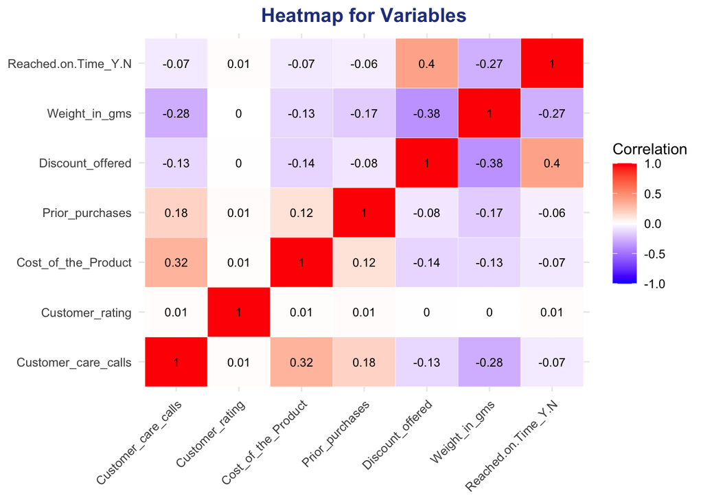

### **Average Number of Customer Care Calls and Delivery Timeliness**

The average number of customer care calls was **4** . The table below shows the comparison of deliveries being on time or not based on whether the number of customer care calls was above or below the average:

|  | Not On Time | On Time |
| --- | --- | --- |
| > Mean Calls | 1577 | 2010 |
| ≤ Mean Calls | 2859 | 4553 |

There is a noticeable trend where higher customer care call frequency correlates with a higher number of late deliveries. This suggests that customers who have more inquiries or problems tend to experience more delivery delays. It can be inferred that customer queries are likely the result of issues with delivery timing. This implies that customer support may not be addressing all issues promptly, or there could be too many queries related to delivery delays.

### **Analysis of High-Importance Products: Ratings and Delivery Timeliness**

We analyzed the high-importance products to determine whether they received the highest customer ratings and whether they were delivered on time.

High Ratings for High-Importance Products: Out of the high-importance products, 186 products received the highest rating. The percentage of high-importance products that received the highest rating is **19.62%**. On-Time Delivery for High-Importance Products: A total of 616 high-importance products were delivered on time, while 332 products were not. The percentage of high-importance products delivered on time is **65%**.

These results highlight that product importance does not necessarily guarantee top ratings or on-time delivery. Both aspects — customer satisfaction (ratings) and delivery performance — are crucial for high-importance products, and further improvements may be needed in both areas.

### Decision Tree Model Evaluation

In this analysis, we explored several machine learning models to predict the On-Time Delivery status. The models tested included:

- **Random Forest**,
- **Logistic Regression**,
- **Cubist Model**,
- **Decision Tree (selected as the most promising model)**

Why Decision Tree?

After evaluating the models, the Decision Tree model showed the most promising results, outshining the others in terms of sensitivity and its ability to clearly interpret the results. Below is the performance evaluation of the Decision Tree model.

Model Performance

ROC Curve and AUC (Area Under the Curve)

The AUC (Area Under the Curve) of 0.74 suggests a moderate ability of the model to differentiate between on-time and late deliveries. The ROC curve further confirms this performance:

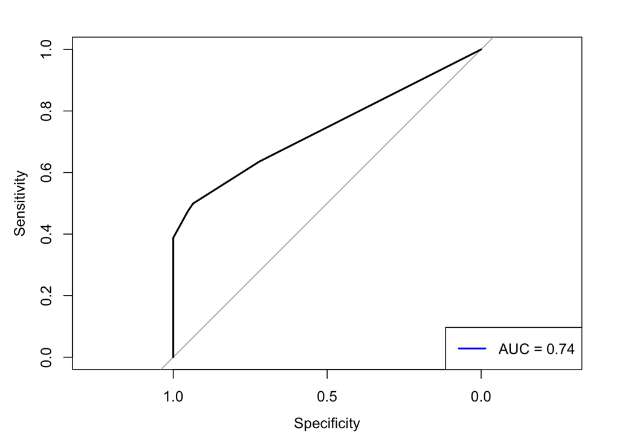

Confusion Matrix Heatmap

I also visualized the Confusion Matrix of the Decision Tree model using a heatmap. The heatmap highlights how many True Positives, True Negatives, False Positives, and False Negatives the model predicted:

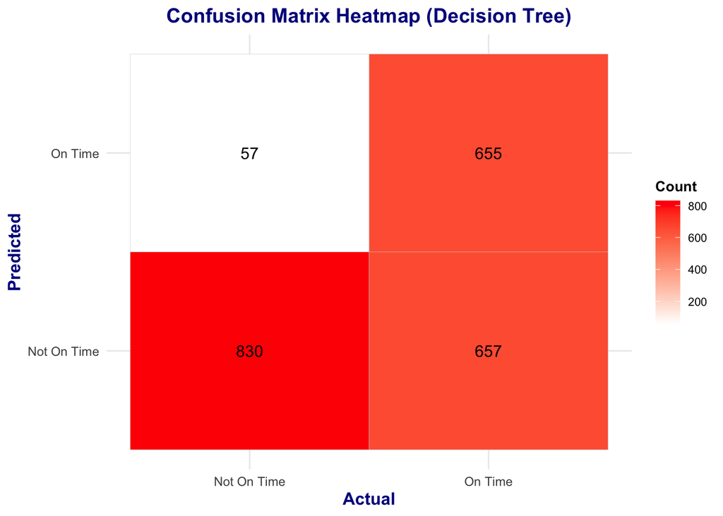

## References

- Data Source: [Kaggle](https://www.kaggle.com/datasets/prachi13/customer-analytics/data)